# Graphs for SocPOP

Joel Ramirez

8/9/2019

# Plotting Our Data

## Read in data and create one dataframe with demographic and outcome information, assuming you already ran data_wrangling!

```r
data_label <- read_csv("./data/data_label.csv") %>%
  select(-X1 )
comment_label <- read_csv("./data/comment_label.csv")

data_demo <- read_csv("./data/data_children.csv") %>%
  mutate(id = as.character(id)) %>%
  select(-c(child_born_US, dad_birth_country, dad_ed_L1_pre,
            DRT_L1_postKnown, DRT_L1_postKnownN, DRT_L1_postKnownSD, notGoodRT_L1_post_reason,
            CDI_age_18m, CDI_understands_words_18m, CDI_produces_words_18m, CDI_age_25m)) %>%
  rename("rt_25m" = "GoodDRT_L1_postKnown", "cdi_25m" = "CDI_vocab_25m")


# merge into 1 dataframe
# note: 168 and 310 will be handcoded for their rt values
socpop <- data_label %>%
  full_join(data_demo, by = "id")
```

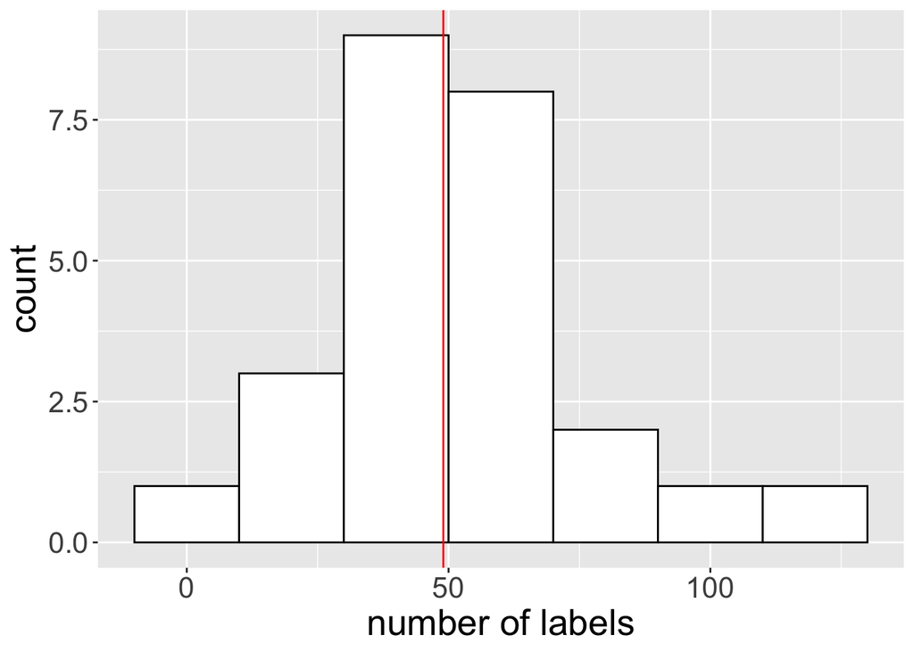

```r
# histogram for labels
ggplot(socpop, aes(x = labels)) +
  geom_histogram(fill = "white", color = "black", binwidth = 20)  +
  labs(x = "number of labels") +
  geom_vline(xintercept = median(data_label$labels), color="red")+
  theme(text = element_text(size=20))
```

```r
sd(data_label$labels)
```

```
## [1] 25.30138
```

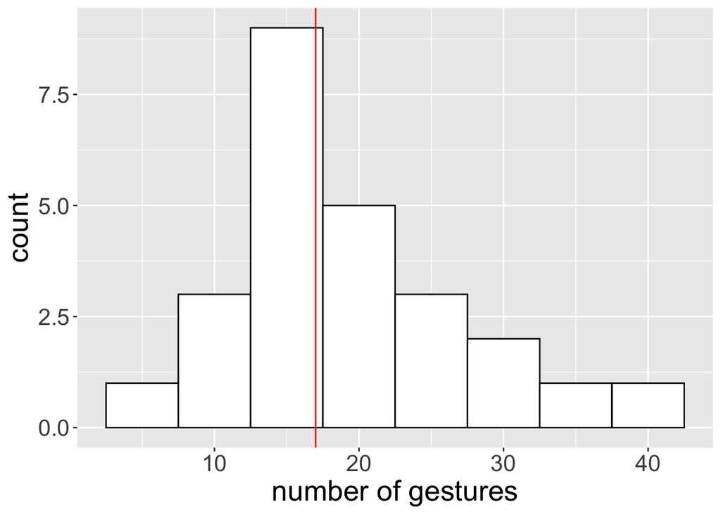

```r
ggsave("./figures/histogram_label.png", height = 8, width = 11, units = "in")

# histogram for gestures
ggplot(socpop, aes(x = gestures)) +
  geom_histogram(fill = "white", color = "black", binwidth = 5) +
  labs(x = "number of gestures") +
  geom_vline(xintercept = median(data_label$gestures), color="red") +
  theme(text = element_text(size=20))
```

```r
sd(data_label$gestures)
```

```
## [1] 8.246818
```

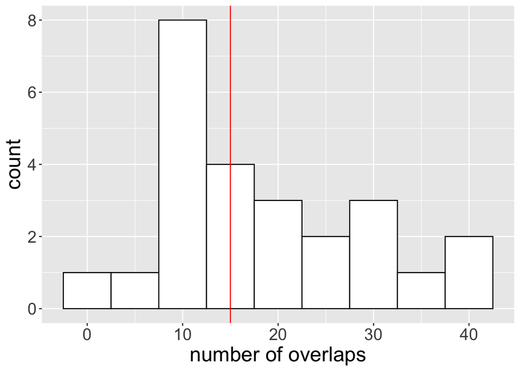

```r
ggsave("./figures/histogram_gesture.png", height = 8, width = 11, units = "in")

# histogram for overlaps
ggplot(socpop, aes(x = labels_w_gestures)) +
  geom_histogram(fill = "white", color = "black", binwidth = 5) +
  labs(x = "number of overlaps")  +
   geom_vline(xintercept = median(data_label$labels_w_gestures), color="red") +
  theme(text = element_text(size=20))
```

```r
sd(data_label$labels_w_gestures)
```

```
## [1] 11.24974
```

```r
ggsave("./figures/histogram_overlaps.png", height = 8, width = 11, units = "in")
```

## Create scatterplots with the line of best fit for Labels & Gestures and Labels & Overlaps

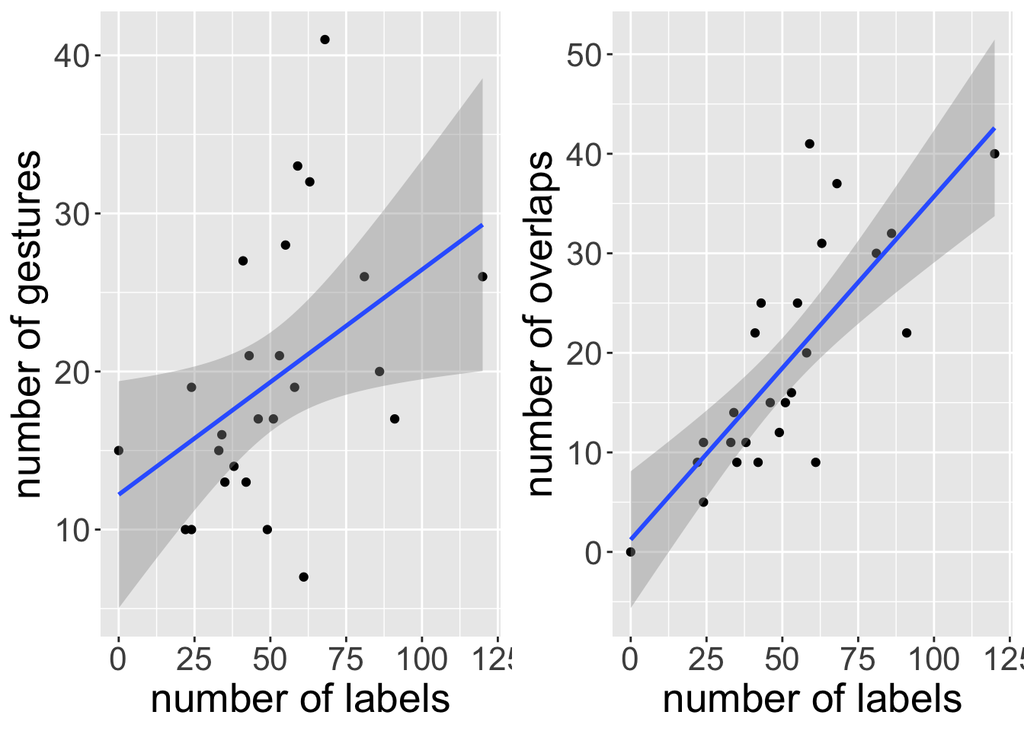

```r
p1 <- ggplot(socpop, aes(x = labels, y = gestures))+
  geom_point()+
 labs(x = "number of labels", y = "number of gestures") +
  geom_smooth(method = "lm") +
   theme(text = element_text(size=20))

ggsave("./figures/plot_labels_gestures.png", height = 8, width = 11, units = "in")

p2 <- ggplot(socpop, aes(x = labels, y = labels_w_gestures))+
  geom_point()+
  geom_smooth(method = "lm") +
  labs(x = "number of labels", y = "number of overlaps") +
  theme(text = element_text(size=20))
ggsave("./figures/plot_labels_overlap.png", height = 8, width = 11, units = "in")

grid.arrange(p1,p2, ncol = 2)
```

## Create data frames to plot against outcome data

```r
rt <- socpop %>%
  select( id, labels, gestures, labels_w_gestures, rt_25m) %>%
   na.omit()

cdi <- socpop %>%
  select( id, labels, gestures, labels_w_gestures, cdi_25m) %>%
  na.omit()
```

## Creating three scatter plots with their lines of best fit. Here we are plotting the three input variables to RT at 25 months.

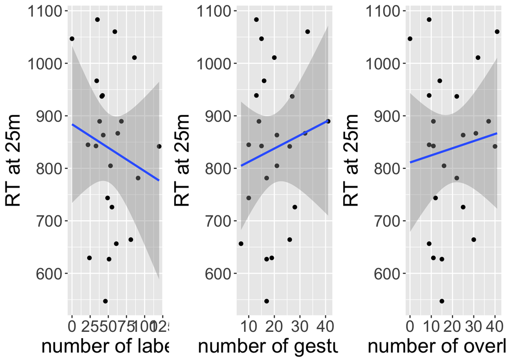

```r
p3 <- ggplot(rt, aes(x = labels, y = rt_25m)) +
  geom_point()+
  geom_smooth(method = "lm")+
  labs( x = "number of labels", y = "RT at 25m") +
  theme(text = element_text(size=20))
p4 <- ggplot(rt, aes(x = gestures, y = rt_25m)) +
  geom_point() +
  geom_smooth(method = "lm") +
  labs( x = "number of gestures", y = "RT at 25m") +
  theme(text = element_text(size=20))
p5 <- ggplot(rt, aes(x = labels_w_gestures, y = rt_25m)) +
  geom_point()+
  geom_smooth(method = "lm")+
  labs( x = "number of overlaps", y = "RT at 25m") +
  theme(text = element_text(size=20))

grid <-grid.arrange(p3, p4, p5, ncol = 3)
```

```r
ggsave("./figures/plot_input_RT.png", plot = grid, height = 8, width = 11, units = "in")
```

## Create three scatterplots with their lines of best fit. Here we are plotting the three input variables to CDI score at 25 months.

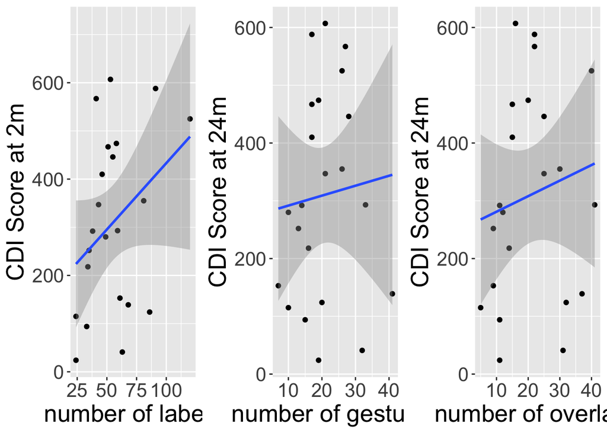

```r
p3 <- ggplot(cdi, aes(x = labels, y = cdi_25m))+
  geom_point()+
  geom_smooth(method = "lm")+
  labs( x = "number of labels", y = "CDI Score at 2m") +
  theme(text = element_text(size=20))
p4 <- ggplot(cdi, aes(x = gestures, y = cdi_25m))+
  geom_point()+
  geom_smooth(method = "lm")+
  labs( x = "number of gestures", y = "CDI Score at 24m") +
  theme(text = element_text(size=20))
p5 <- ggplot(cdi, aes(x = labels_w_gestures, y = cdi_25m)) +
  geom_point()+
  geom_smooth(method = "lm")+
  labs( x = "number of overlaps", y = "CDI Score at 24m") +
  theme(text = element_text(size=20))

grid <- grid.arrange(p3, p4, p5, ncol = 3)
```

```r
ggsave("./figures/plot_input_cdi.png", plot = grid, height = 8, width = 11, units = "in")
```

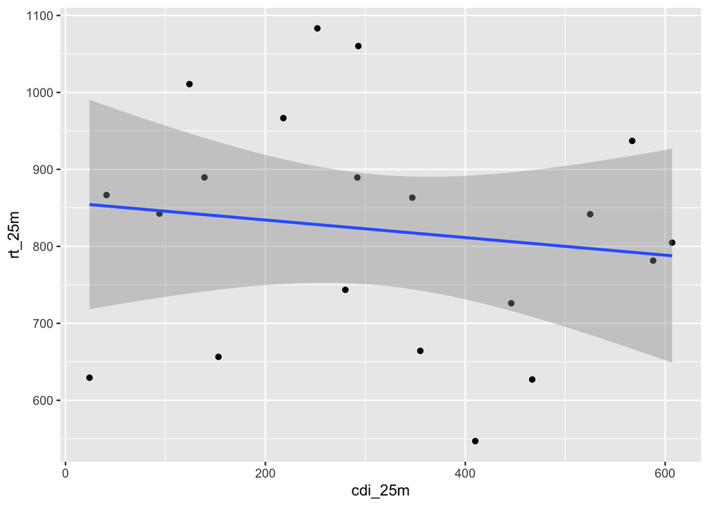

```r
  cdi_rt <- socpop %>%
  select(id, cdi_25m, rt_25m) %>%
  na.omit()

 ggplot(cdi_rt, aes(x = cdi_25m, y = rt_25m))+
  geom_point()+
  geom_smooth(method = "lm")
```

```r
cor.test(cdi_rt$cdi_25m, cdi_rt$rt_25m)
```

```
##
##  Pearson's product-moment correlation
##
## data:  cdi_rt$cdi_25m and cdi_rt$rt_25m
## t = -0.59624, df = 18, p-value = 0.5584
## alternative hypothesis: true correlation is not equal to 0
## 95 percent confidence interval:
##  -0.5479429  0.3232619
## sample estimates:
##        cor
## -0.1391667
```

## Here are all the correlations and their 95% confidence interval

```r
rt_matrix<- rt %>%
  select(-id)
rcorr(as.matrix(rt_matrix))
```

```
##                   labels gestures labels_w_gestures rt_25m
## labels              1.00     0.41              0.76  -0.15
## gestures            0.41     1.00              0.83   0.14
## labels_w_gestures   0.76     0.83              1.00   0.10
## rt_25m             -0.15     0.14              0.10   1.00
##
## n= 23
##
##
## P
##                   labels gestures labels_w_gestures rt_25m
## labels                   0.0541   0.0000            0.4817
## gestures          0.0541          0.0000            0.5177
## labels_w_gestures 0.0000 0.0000                     0.6381
## rt_25m            0.4817 0.5177   0.6381
```

```r
cdi_matrix<- cdi %>%
  select(-id)

rcorr(as.matrix(cdi_matrix))
```

```
##                   labels gestures labels_w_gestures cdi_25m
## labels              1.00     0.38              0.72    0.35
## gestures            0.38     1.00              0.85    0.08
## labels_w_gestures   0.72     0.85              1.00    0.16
## cdi_25m             0.35     0.08              0.16    1.00
##
## n= 22
##
##
## P
##                   labels gestures labels_w_gestures cdi_25m
## labels                   0.0842   0.0001            0.1082
## gestures          0.0842          0.0000            0.7283
## labels_w_gestures 0.0001 0.0000                     0.4818
## cdi_25m           0.1082 0.7283   0.4818
```

```r
cor.test(rt_matrix$labels, rt_matrix$rt_25m)
```

```
##
##  Pearson's product-moment correlation
##
## data:  rt_matrix$labels and rt_matrix$rt_25m
## t = -0.71623, df = 21, p-value = 0.4817
## alternative hypothesis: true correlation is not equal to 0
## 95 percent confidence interval:
##  -0.5327136  0.2753062
## sample estimates:
##        cor
## -0.1544198
```

```r
cor.test(rt_matrix$gestures, rt_matrix$rt_25m)
```

```
##
##  Pearson's product-moment correlation
##
## data:  rt_matrix$gestures and rt_matrix$rt_25m
## t = 0.65794, df = 21, p-value = 0.5177
## alternative hypothesis: true correlation is not equal to 0
## 95 percent confidence interval:
##  -0.2868924  0.5236430
## sample estimates:
##       cor
## 0.1421161
```

```r
cor.test(rt_matrix$labels_w_gestures, rt_matrix$rt_25m)
```

```
##
##  Pearson's product-moment correlation
##
## data:  rt_matrix$labels_w_gestures and rt_matrix$rt_25m
## t = 0.47723, df = 21, p-value = 0.6381
## alternative hypothesis: true correlation is not equal to 0
## 95 percent confidence interval:
##  -0.3223875  0.4946615
## sample estimates:
##       cor
## 0.1035792
```

```r
cor.test(cdi_matrix$labels, cdi_matrix$cdi_25m)
```

```
##
##  Pearson's product-moment correlation
##
## data:  cdi_matrix$labels and cdi_matrix$cdi_25m
## t = 1.6816, df = 20, p-value = 0.1082
## alternative hypothesis: true correlation is not equal to 0
## 95 percent confidence interval:
##  -0.08177853  0.67361489
## sample estimates:
##       cor
## 0.3519652
```

```r
cor.test(cdi_matrix$gestures, cdi_matrix$cdi_25m)
```

```
##
##  Pearson's product-moment correlation
##
## data:  cdi_matrix$gestures and cdi_matrix$cdi_25m
## t = 0.35224, df = 20, p-value = 0.7283
## alternative hypothesis: true correlation is not equal to 0
## 95 percent confidence interval:
##  -0.3548345  0.4841030
## sample estimates:
##        cor
## 0.07852074
```

```r
cor.test(cdi_matrix$labels_w_gestures, cdi_matrix$cdi_25m)
```

```
##
##  Pearson's product-moment correlation
##
## data:  cdi_matrix$labels_w_gestures and cdi_matrix$cdi_25m
## t = 0.71681, df = 20, p-value = 0.4818
## alternative hypothesis: true correlation is not equal to 0
## 95 percent confidence interval:
##  -0.2821723  0.5436007
## sample estimates:
##       cor
## 0.1582643
```

## Creates the necessary data frame for proportion of labels and accompanying gestures and plots it in a histogram.

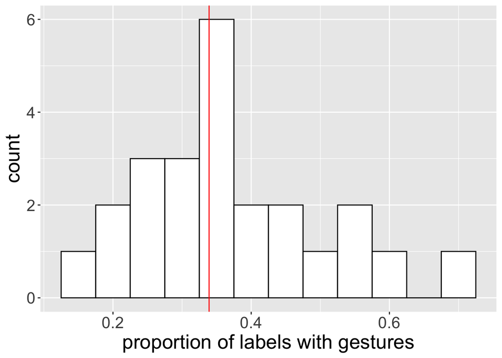

```r
socpop <- socpop %>%
  mutate(prop_overlaps_labels = labels_w_gestures/labels)

ggplot(socpop, aes(x = prop_overlaps_labels)) +
   geom_histogram(fill = "white", color = "black", binwidth = .05) +
  geom_vline(xintercept = median(socpop$prop_overlaps_labels, na.rm = TRUE), color="red") +
  labs(x = "proportion of labels with gestures") +
  theme(text = element_text(size=20))
```

```r
  ggsave("./figures/hist_prop_overlaps_labels.png",height = 8, width = 11, units = "in")
```